# final_template

Hibah Ganie

2025-06-10

## [Hibah’s Github Repository](https://github.com/hibdawg/ENVS-193DS_spring-2025_final)

```r
library(tidyverse) # General use
library(janitor) # Cleaning data Frames
library(dplyr) # Mutate columns
library(lubridate) # make dealing with dates easier
library(here) # File Organization
```

```r
library(readxl) # reading .xlsx files
library(ggeffects) # generating model predictions
library(gtsummary) # generating summary tables for models
library(ggplot2) # visualizations
library(hms) # working with times
library(MuMIn) # For building Model
library(DHARMa) # For viewing residuals
sst <- read_csv(here("data", "SST_update2023.csv")) # read in sea surface temperature data
parrot <- read_csv(
  # read in data and specify file path
  here("data", "occdist.csv"))
```

# Problem 1. Research Writing

## a. Transparent statistical methods

[In part one they used a correlation test to determine how two variables, distance from headwater (km) and annual total nitrogen load (kg year^-1) relate or are associated with eachother. My coworker also use an ANOVA in part 2 to compare the means of more than two groups.]

## b. More information needed

[Accepting uncertainty is key in interpreting analysis of variance, and can be conducted through communicating the confidence intervals, such as the CI of the difference between urban land, atmospheric deposition, fertilizer, waste water treatment, and grasslands.Tukey’s Honestly Signifiant difference can be used to further investigate which groups are different when compares, giving information on pairwise comparison, difference in means between groups, and adjusted p-value to increase transparency.Effect size can also be used to determine how strongly distance from headwaters (KM) effects the annual total nitrogen load (kg year^-1) found between groups.]

## c. Suggestions for rewriting

[We found a negligible difference (n^2= effect size) between groups in mean nitrogen load (One-Way Anova, F-distribution(among groups Degrees of Freedom,within group Degrees of Freedom) = f-value, p < 0.02, $\alpha$ = significance level)

On average, there was little difference of nitrogen load between urban land, atmospheric deposition, fertilizer, waste water treatment and grasslands (Tukey HSD difference, % Confidence Interval:CI, CI based on distance from headwaters (KM)) ]

# Problem 2. Data Visualization

## a. Cleaning and Summarizing

```r
sst_clean <- sst |>
  # select sst data frame
  clean_names() |>
  # remove spaces and uppercase letters (cleans)
  mutate( # mutate function to change formatting of date, year, and month using lubridate package
    date = ymd(date), #year, month, date formate for date column
    year = year(date), # change from chr to num for year
    month = month(date, label = TRUE, abbr = TRUE) # change month to an ordered factor and abbreviate
  ) |>
  filter(year >= 2018) |>
  # filters years to after 2018
  mutate(
    year = factor(year), # convert year to factor
    month = factor(month, levels = month.abb, ordered = TRUE) # month as a factor
  ) |>
  group_by(year, month) |>
  # group together year and month for mean monthly SST calculation
  summarise(mean_monthly_sst =
              mean(temp, na.rm = TRUE),
            .groups = "drop") |>
  # Calculate mean monthly sst and ignore missing values, then drop the grouping
  mutate(
    mean_monthly_sst = (format(round(mean_monthly_sst, 1), nsmall = 1) # round values to one decimal point
  )) |>
  # One last mutate to convert from chr to number, or dbl format
  mutate(
    mean_monthly_sst =
      as.numeric(mean_monthly_sst)
  )

# Randomly display 5 rows from sst_clean data frame
sst_clean |>
  slice_sample(n = 5)
```

```
## # A tibble: 5 × 3
##   year  month mean_monthly_sst
##   <fct> <ord>            <dbl>
## 1 2020  Dec               14.5
## 2 2019  Dec               15
## 3 2020  May               14.6
## 4 2022  Sep               19.3
## 5 2022  Jan               13.9
```

```r
#display structure of dataframe
str(sst_clean)
```

```
## tibble [72 × 3] (S3: tbl_df/tbl/data.frame)
##  $ year            : Factor w/ 6 levels "2018","2019",..: 1 1 1 1 1 1 1 1 1 1 ...
##  $ month           : Ord.factor w/ 12 levels "Jan"<"Feb"<"Mar"<..: 1 2 3 4 5 6 7 8 9 10 ...
##  $ mean_monthly_sst: num [1:72] 15 14.3 13.5 12.8 13.6 15.5 18.2 19.6 18.2 18.5 ...
```

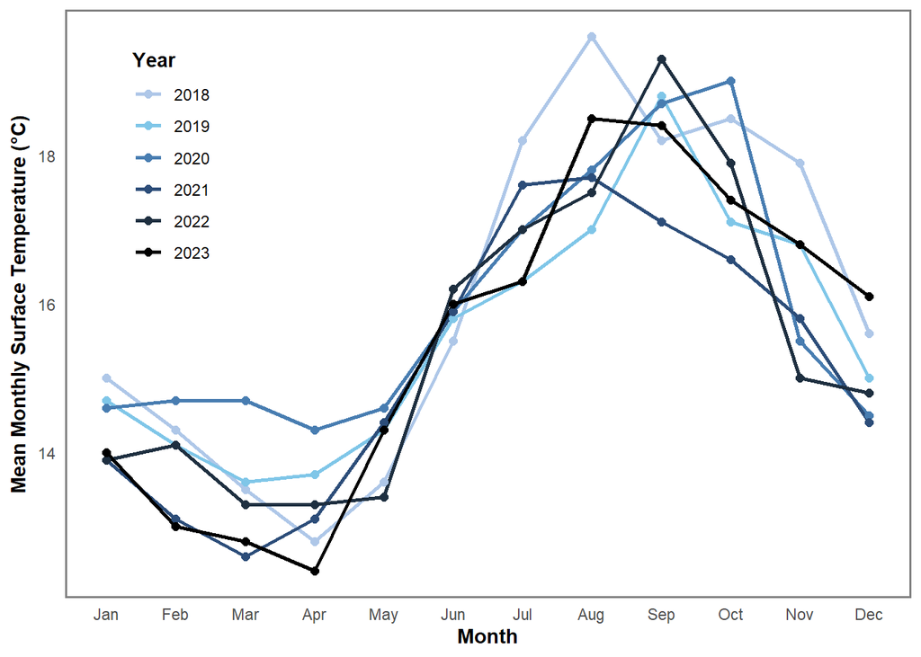

```r
ggplot(data = sst_clean, # select cleaned data frame
       aes(x=month, # x axis as month
           y=mean_monthly_sst, # y axis as mean monthly sea surface temperature
           group = year,# group by year so a separate line shows up for each year
           color= factor(year))) + # each year as a factor
  geom_line(linewidth = 1) + # select thickness of line
  geom_point(size = 2) + # select size of point
  scale_color_manual( # manually choose colors
    values= c( # c, for list of colors
      "2018" = "#aec7e8",
      "2019" = "#7fc6e8",
      "2020" = "#487db1",
      "2021" = "#2c4d79",
      "2022" = "#1e2f40",
      "2023" = "#000000"
      )) +
  labs(x = substitute(paste(bold('Month'))), # label x, y, and legend as well as bold
       y = substitute(paste(bold("Mean Monthly Surface Temperature (°C)"))),
       color = substitute(paste(bold("Year"))),
       ) +
  theme( # custom theme to remove all elements except add gray border
    panel.background = element_rect(
      fill = "white",
      colour = NA),       # white panel fill, no border here
    panel.border = element_rect(
      fill = NA,
      colour = "#808080",
      size = 1),  # size of border
    plot.background  = element_rect(fill = "white", colour = NA), # remove any color
    panel.grid.major = element_blank(), # make everything blank
    panel.grid.minor = element_blank(),
    axis.ticks        = element_blank()) +
  theme(
    legend.position = c(.16,.95), # position graph in top left corner
    legend.justification = c(.8,1) # specify other corner
  )
```

# Problem 3: Data Analysis

## a.

[The ones in this data set represent an presence of bird within each column, meaning presence of swift parrot, common starling, unoccupied, or tree martin within each categorical column for each species. The 0s indicate that the box for each category is other species, empty, or occupied.]

## b.

[Swift parrots are nomadic, critically endangered due to deforestation and predation, and rarely breed in the same location. The selective nature of swift parrots is different from common starlings and Tree Martins, which are generalists and can easily compete with swift parrots for nest boxes.]

## c.

[The two years the authors looked at were 2016 and 2019 during breeding times for swift parrots stimulated by mast tree flowering event. Swift parrots are not known to occupy repeat breeding sites, so the second season tests how permanent next boxes are utilized by swift parrots and non-target species.]

## d.

| Model number | Season | Distance to Forest Edge | Model Description |
| --- | --- | --- | --- |
| 0 |  |  | No predictors (null model) |
| 1 | X | X | all predictors (full model) |
| 2 | X |  | Season Only |
| 3 |  | X | Distance to Forest Edge Only |

## e.

```r
parrot_clean <- parrot |>
  # select orginal data frame
  clean_names() |>
  # remove spaces and upercases
   mutate( # create new column for swift parrot
    swift_parrot = box_occupant == "swift parrot"
  ) |>
  # create new column for season/year and make it a factor
  mutate(
    season = as.factor(season)
  ) |>
  # select which columns i want
  select(
    box_occupant,
    edge_distance,
    season,
    swift_parrot
         ) |>
  # swift parrot as a factor for modeling
  mutate(
    swift_parrot = as.factor(swift_parrot)
  )
```

```r
# model 0: null model
model0 <- glm(
  swift_parrot ~ 1, # Null model ,no other variables
  data = parrot_clean, # DF
  family = "binomial" # binomial distribution, swift parrot or not
)

#model !: Saturated Model
model1 <- glm(
  swift_parrot ~ season + edge_distance, # account for season and distance from forest
  data = parrot_clean,
  family = "binomial"
)

# model 2: Univariate Model: distance from edge
model2 <- glm(
  swift_parrot ~ season, # Only account for season
  data = parrot_clean,
  family = "binomial"
)

# model 3: Univariate Model: Season
model3 <- glm(
  swift_parrot ~ edge_distance, # only account for distance from edge
  data = parrot_clean,
  family = "binomial"
)
```

```r
# Use DHARMa Package to simulate residuals for each model
residuals0 = simulateResiduals(model0)
residuals1 = simulateResiduals(model1)
residuals2 = simulateResiduals(model2)
residuals3 = simulateResiduals(model3)
```

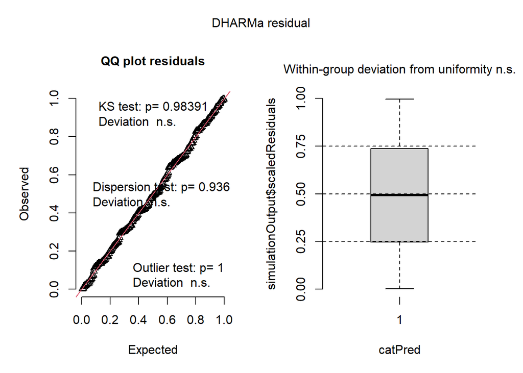

```r
# Use DHARMa Package to plot residuals
par(mfrow = c(2,2))
plot(residuals0)
```

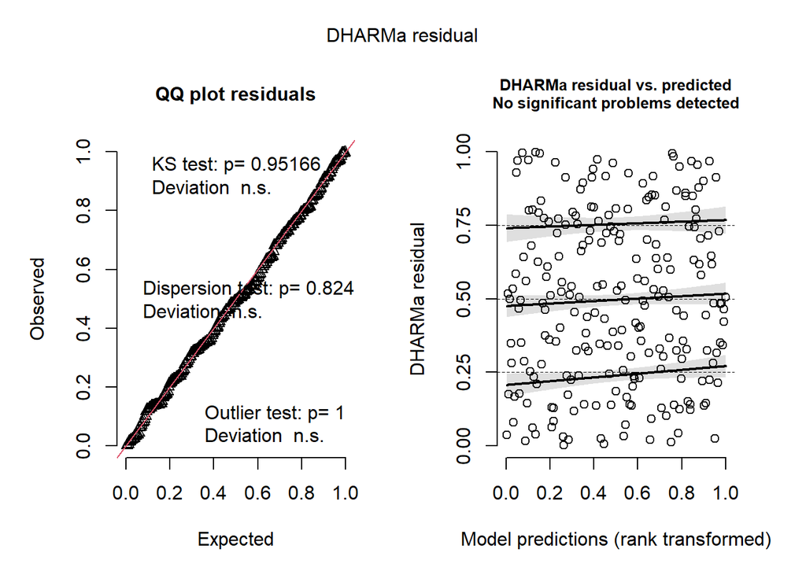

```r
par(mfrow = c(2,2))
plot(residuals1)
```

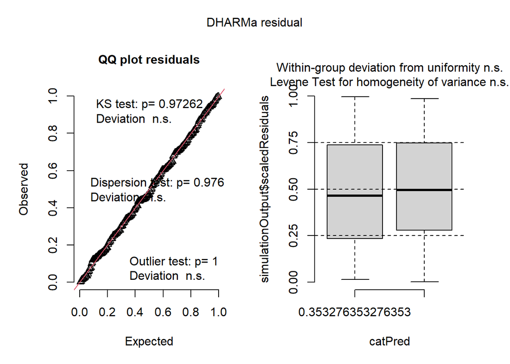

```r
par(mfrow = c(2,2))
plot(residuals2)
```

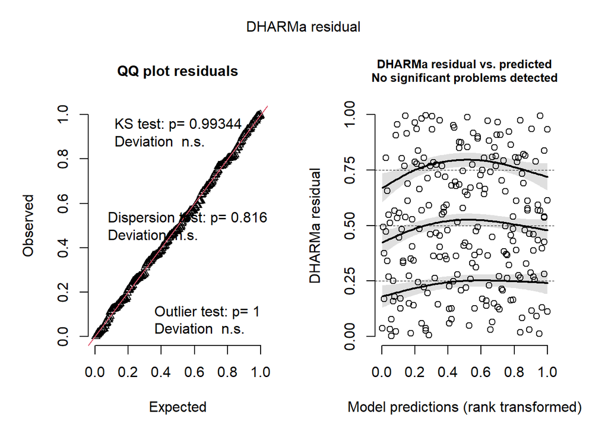

```r
par(mfrow = c(2,2))
plot(residuals3)
```

```r
AICc(model0,
     model1, # Lowest AIC @ 226.3133
     model2,
     model3) |>
  # arranging output in descending order of AIC
  arrange(AICc)
```

```
##        df     AICc
## model1  3 226.3133
## model3  2 229.6716
## model2  2 236.3744
## model0  1 238.8318
```

# G. Select the Best Model

[Determined through Aikaike Information Criterion, the saturated model that considered both season and distance from forest edge was the best fit. The best model predicts swift parrots (species) habitation of nest boxes during breeding season includes season (year) and distance from forest edge (m)]

# H. Visualize Model Predictions

```r
mod_preds <- ggpredict(
  model1, # model Object
  terms = c("edge_distance", "season") # predictors
  )
```

```
## Data were 'prettified'. Consider using `terms="edge_distance [all]"` to
##   get smooth plots.
```

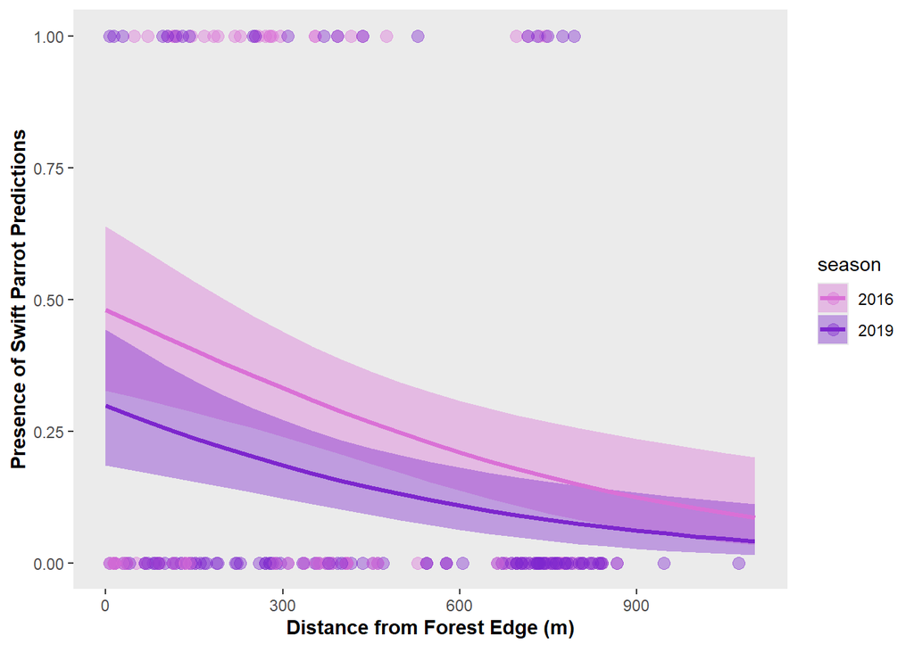

```r
# Picking colors for each layer of visualization
mycolors <- c("2016" = "orchid",
              "2019" = "purple3")

ggplot(parrot_clean, # background data, include scatterplots
       aes(x = edge_distance,
           y = as.numeric(swift_parrot) -1 # include data despite factor stucture
           )
       ) +
  geom_point(aes(color = season), # color based on year/season
             size = 3,
             alpha = 0.4) +
  labs(x = substitute(paste(bold('Distance from Forest Edge (m)'))), # label x, y, and legend as well as bold
       y = substitute(paste(bold("Presence of Swift Parrot Predictions"))),
       color = substitute(paste(bold("Year"))),
       ) +
  # add 95% confidence interval
  geom_ribbon(data = mod_preds,
              aes(x = x,
                  y = predicted,
                  ymin = conf.low,
                  ymax = conf.high,
                  fill = group),
              alpha = 0.4,
              inherit.aes = FALSE) +
# add line layer to data with model predictions and group by year/season
  geom_line(data = mod_preds,
            aes(x = x,
                y = predicted,
                color = group),
            size = 1.2,
            inherit.aes = FALSE) +
  #manually set colors to previously defined colors
  scale_color_manual(values = mycolors) +
  scale_fill_manual(values = mycolors) +
  # set scale
  scale_y_continuous(limits = c(0,1)) +
  labs(color = "season",
       fill = "season") +
  # remoce grids
  theme(
  panel.grid.major = element_blank(), # make everything blan
  panel.grid.minor = element_blank())
```

# i. Write a Caption [Figure 2. Prescense of Swift Parrot Predictions vs Distance from Forest Edge across seasons, 2016 and 2019. The figure displays predictions of swift parrot presence as distance from the forest edge increases. Stojanovic, Dejan et al. (2021). https://doi.org/10.5061/dryad.83bk3j9sb]

# j. Calculate Model Predictions

[If the forest edge is 0m away the probability of Swift Parrot Occupancy in 2016 is .48(95%CI[0.33, 0.64])

If the forest edge is 900m away the probability of Swift Parrot Occupancy in 2016 is .12(95%CI[0.06, 0.24])

If the forest edge is 0m away the probability of Swift Parrot Occupancy in 2019 is .30(95%CI[0.18, 0.44])

If the forest edge is 900m away the probability of Swift Parrot Occupancy in 2019 is .06(95%CI[0.03, 0.13])]

```r
# model formula, select for distance from forest and season/year
ggpredict(model1,
          terms = c("edge_distance [0]", "season[2016]"))
```

```
## # Predicted probabilities of swift_parrot
##
## edge_distance | Predicted |     95% CI
## --------------------------------------
##             0 |      0.48 | 0.33, 0.64
```

```r
ggpredict(model1,
          terms = c("edge_distance [900]", "season[2016]"))
```

```
## # Predicted probabilities of swift_parrot
##
## edge_distance | Predicted |     95% CI
## --------------------------------------
##           900 |      0.12 | 0.06, 0.24
```

```r
ggpredict(model1,
          terms = c("edge_distance [0]", "season[2019]"))
```

```
## # Predicted probabilities of swift_parrot
##
## edge_distance | Predicted |     95% CI
## --------------------------------------
##             0 |      0.30 | 0.18, 0.44
```

```r
ggpredict(model1,
          terms = c("edge_distance [900]", "season[2019]"))
```

```
## # Predicted probabilities of swift_parrot
##
## edge_distance | Predicted |     95% CI
## --------------------------------------
##           900 |      0.06 | 0.03, 0.13
```

# K. Describe Your Results

[Swift parrots tend to occupy nest boxes at a higher frequency when closer to the edge of the forest. Furthermore, occupancy typically decreases with time, with the inital breeding season data recieving higher prescence of swift parrots.

Likely swift parrot’s specialist preference for tree cavities and dislike for resuing previous breeding locations is behind the declining occupancy prediction with distance from forest and subsequent season since 2016.]

## Problem 4. Affective and exploratory visualizations

[I attended every workshop except week ten’s because I got sick :( ]